# Problem Set 4

Baskaran Viswanathan

September 15, 2015

# Q1) Price vs. x

```
## 'data.frame':    53940 obs. of  10 variables:
##  $ carat  : num  0.23 0.21 0.23 0.29 0.31 0.24 0.24 0.26 0.22 0.23 ...
##  $ cut    : Ord.factor w/ 5 levels "Fair"<"Good"<..: 5 4 2 4 2 3 3 3 1 3 ...
##  $ color  : Ord.factor w/ 7 levels "D"<"E"<"F"<"G"<..: 2 2 2 6 7 7 6 5 2 5 ...
##  $ clarity: Ord.factor w/ 8 levels "I1"<"SI2"<"SI1"<..: 2 3 5 4 2 6 7 3 4 5 ...
##  $ depth  : num  61.5 59.8 56.9 62.4 63.3 62.8 62.3 61.9 65.1 59.4 ...
##  $ table  : num  55 61 65 58 58 57 57 55 61 61 ...
##  $ price  : int  326 326 327 334 335 336 336 337 337 338 ...
##  $ x      : num  3.95 3.89 4.05 4.2 4.34 3.94 3.95 4.07 3.87 4 ...
##  $ y      : num  3.98 3.84 4.07 4.23 4.35 3.96 3.98 4.11 3.78 4.05 ...
##  $ z      : num  2.43 2.31 2.31 2.63 2.75 2.48 2.47 2.53 2.49 2.39 ...
```

```r
library(ggplot2)
library(dplyr)
data(diamonds)

str(diamonds)
```

# Q2) Findings - price vs. x

looks like there is a linear like relationship between ln(price) and x value. and no X values for some ln(price) valuse between where ln(price)= 7 and 8

There are some outliers such as zero X value and postive price value.

# Q3) Correlations

What is the correlation between price and x? What is the correlation between price and y? What is the correlation between price and z?

```r
with(diamonds, cor.test(x=price, y = x, method = 'pearson'))
```

```
##
##  Pearson's product-moment correlation
##
## data:  price and x
## t = 440.16, df = 53938, p-value < 2.2e-16
## alternative hypothesis: true correlation is not equal to 0
## 95 percent confidence interval:
##  0.8825835 0.8862594
## sample estimates:
##       cor
## 0.8844352
```

```r
with(diamonds, cor.test(x=price, y = y, method = 'pearson'))
```

```
##
##  Pearson's product-moment correlation
##
## data:  price and y
## t = 401.14, df = 53938, p-value < 2.2e-16
## alternative hypothesis: true correlation is not equal to 0
## 95 percent confidence interval:
##  0.8632867 0.8675241
## sample estimates:
##       cor
## 0.8654209
```

```r
with(diamonds, cor.test(x=price, y = z, method = 'pearson'))
```

```
##
##  Pearson's product-moment correlation
##
## data:  price and z
## t = 393.6, df = 53938, p-value < 2.2e-16
## alternative hypothesis: true correlation is not equal to 0
## 95 percent confidence interval:
##  0.8590541 0.8634131
## sample estimates:
##       cor
## 0.8612494
```

# Q4) price vs. depth

Create a simple scatter plot of price vs depth.

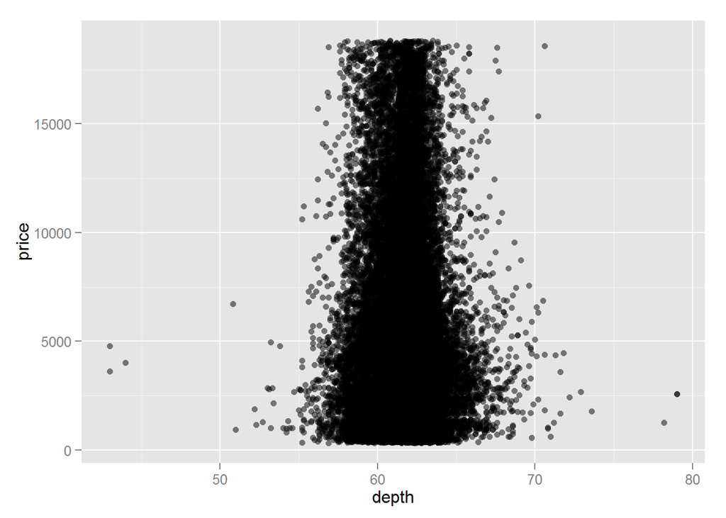

```r
ggplot(data = diamonds, aes(x = depth,y = price)) +
  geom_point(alpha= 0.5)
```

# Q5) Adjustments - price vs. depth

Change the code to make the transparency of the points to be 1/100 of what they are now and mark the x-axis every 2 units. See the instructor notes for two hints.

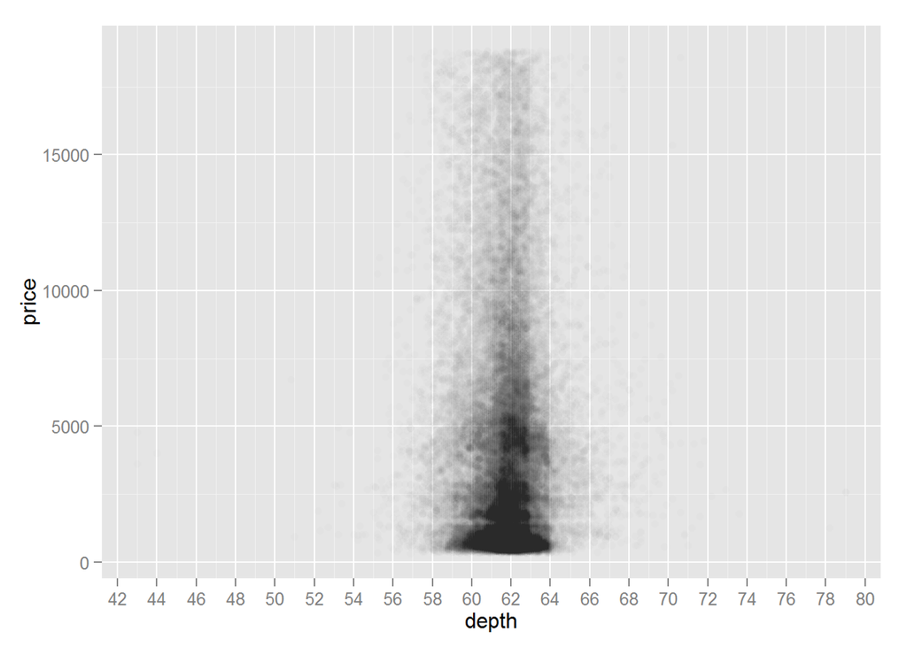

```r
ggplot(data = diamonds, aes(x = depth,y = price)) +
  geom_point(alpha= 0.01) +
  scale_x_continuous(breaks = seq(0,80,2))
```

# Q6) Typical Depth Range

Based on the scatterplot of depth vs price, most diamonds are between what values of depth? Answer: 60 - 64

# Q7) Correlation - price and depth

what is the correlation of depth and price?

```r
with(diamonds, cor.test(x= depth, y = price, method = "pearson"))
```

```
##
##  Pearson's product-moment correlation
##
## data:  depth and price
## t = -2.473, df = 53938, p-value = 0.0134
## alternative hypothesis: true correlation is not equal to 0
## 95 percent confidence interval:
##  -0.019084756 -0.002208537
## sample estimates:
##        cor
## -0.0106474
```

We can say there is almost no correlation between depth and price since correlation coefficient is close to zero.

# Q8) price vs. carat

Create a scatterplot of price vs carat and omit the top 1% of price and carat values.

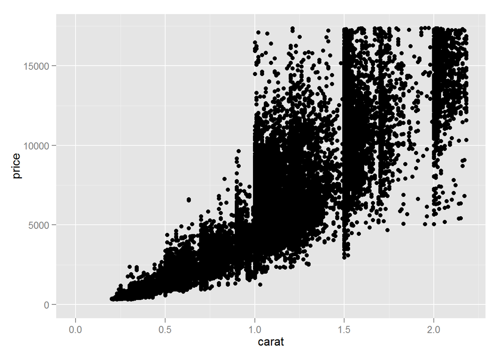

```r
ggplot(data = diamonds,aes(x = carat, y = price)) +
  xlim(0,quantile(diamonds$carat,0.99)) +
  ylim(0,quantile(diamonds$price,0.99)) +
  geom_point()
```

# Q9) price vs. volume

Create a scatterplot of price vs. volume (x * y * z). This is a very rough approximation for a diamond’s volume.

Create a new variable for volume in the diamonds data frame. This will be useful in a later exercise.

```r
diamonds$volume <- diamonds$x*diamonds$y*diamonds$z

head(diamonds,3)
```

```
##   carat     cut color clarity depth table price    x    y    z   volume
## 1  0.23   Ideal     E     SI2  61.5    55   326 3.95 3.98 2.43 38.20203
## 2  0.21 Premium     E     SI1  59.8    61   326 3.89 3.84 2.31 34.50586
## 3  0.23    Good     E     VS1  56.9    65   327 4.05 4.07 2.31 38.07688
```

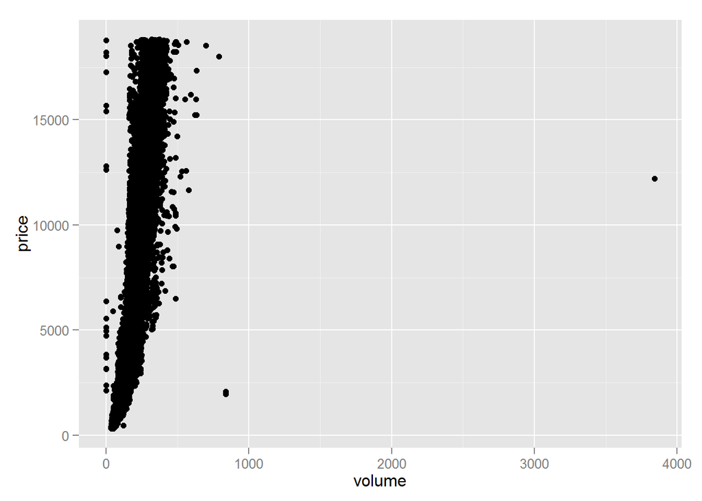

```r
ggplot(data = diamonds, aes(x = volume, y = price)) +
  geom_point()
```

```r
# Some outliers with zero volume

sum(diamonds$volume == 0)
```

```
## [1] 20
```

```r
diamonds[diamonds$volume == 0,]
```

```
##       carat       cut color clarity depth table price    x    y z volume
## 2208   1.00   Premium     G     SI2  59.1    59  3142 6.55 6.48 0      0
## 2315   1.01   Premium     H      I1  58.1    59  3167 6.66 6.60 0      0
## 4792   1.10   Premium     G     SI2  63.0    59  3696 6.50 6.47 0      0
## 5472   1.01   Premium     F     SI2  59.2    58  3837 6.50 6.47 0      0
## 10168  1.50      Good     G      I1  64.0    61  4731 7.15 7.04 0      0
## 11183  1.07     Ideal     F     SI2  61.6    56  4954 0.00 6.62 0      0
## 11964  1.00 Very Good     H     VS2  63.3    53  5139 0.00 0.00 0      0
## 13602  1.15     Ideal     G     VS2  59.2    56  5564 6.88 6.83 0      0
## 15952  1.14      Fair     G     VS1  57.5    67  6381 0.00 0.00 0      0
## 24395  2.18   Premium     H     SI2  59.4    61 12631 8.49 8.45 0      0
## 24521  1.56     Ideal     G     VS2  62.2    54 12800 0.00 0.00 0      0
## 26124  2.25   Premium     I     SI1  61.3    58 15397 8.52 8.42 0      0
## 26244  1.20   Premium     D    VVS1  62.1    59 15686 0.00 0.00 0      0
## 27113  2.20   Premium     H     SI1  61.2    59 17265 8.42 8.37 0      0
## 27430  2.25   Premium     H     SI2  62.8    59 18034 0.00 0.00 0      0
## 27504  2.02   Premium     H     VS2  62.7    53 18207 8.02 7.95 0      0
## 27740  2.80      Good     G     SI2  63.8    58 18788 8.90 8.85 0      0
## 49557  0.71      Good     F     SI2  64.1    60  2130 0.00 0.00 0      0
## 49558  0.71      Good     F     SI2  64.1    60  2130 0.00 0.00 0      0
## 51507  1.12   Premium     G      I1  60.4    59  2383 6.71 6.67 0      0
```

Looks like there is a correlation, however there are few outlier with high volume with low price makes it hard to see the correlation. Also some (20) diamonds have zero volume

# Q10) Correlations on Subsets

What is the correlation of price and volume? Exclude the diamonds that have a volume of 0 or greater than or equal to 800.

```r
with(subset(diamonds, (volume > 0) & (volume <= 800)),cor.test(volume,price))
```

```
##
##  Pearson's product-moment correlation
##
## data:  volume and price
## t = 559.19, df = 53915, p-value < 2.2e-16
## alternative hypothesis: true correlation is not equal to 0
## 95 percent confidence interval:
##  0.9222944 0.9247772
## sample estimates:
##       cor
## 0.9235455
```

# Q11) Adjustments - price vs. volume

Subset the data to exclude diamonds with a volume greater than or equal to 800. Also, exclude diamonds with a volume of 0. Adjust the transparency of the points and add a linear model to the plot. (See the Instructor Notes or look up the documentation of geom_smooth() for more details about smoothers.)

We encourage you to think about this next question and to post your thoughts in the discussion section.

Do you think this would be a useful model to estimate the price of diamonds? Why or why not?

```
## geom_smooth: method="auto" and size of largest group is >=1000, so using gam with formula: y ~ s(x, bs = "cs"). Use 'method = x' to change the smoothing method.
```

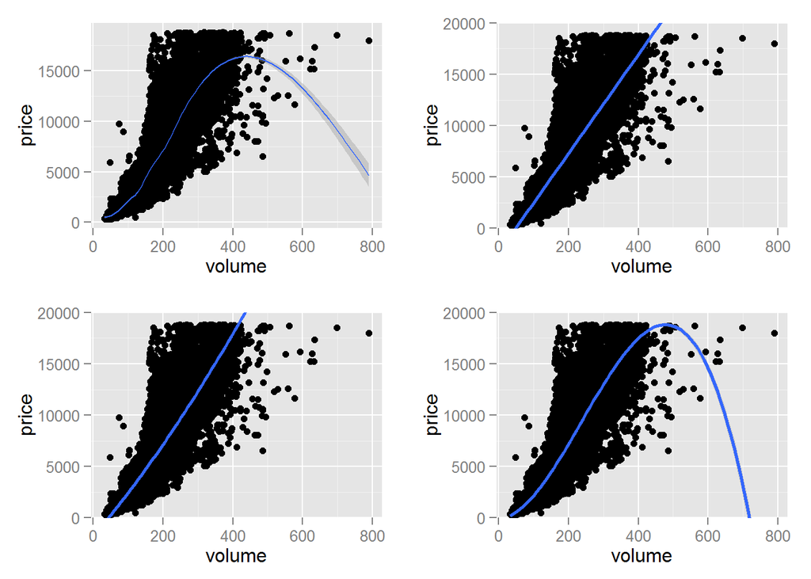

```r
p1 <- ggplot(data = subset(diamonds, (volume > 0) & (volume <= 800)),
       aes(x = volume, y = price)) +
  geom_point()

# Default smoother
p2 <- p1 + geom_smooth()

# looking at a linear fit,
p3 <- p1 + stat_smooth(method = "lm", formula = y ~ x, size = 1) + coord_cartesian(ylim = c(0,20000))

# Looking at polynimoal functions of order 2
p4 <- p1 + stat_smooth(method = "lm", formula = y ~ poly(x, 2), size = 1) + coord_cartesian(ylim = c(0,20000))

# Looking at polynimoal functions of order 3
p5 <- p1 + stat_smooth(method = "lm", formula = y ~ poly(x, 3), size = 1) + coord_cartesian(ylim = c(0,20000))

library(gridExtra)
## Loading required package: grid

grid.arrange(p2,p3,p4,p5,ncol =2)
```

# Q12) Mean Price by Clarity

Use the function dplyr package to create a new data frame containing info on diamonds by clarity. Name the data frame diamondsByClarity

The data frame should contain the following variables in this order. (1) mean_price (2) median_price (3) min_price (4) max_price (5) n

where n is the number of diamonds in each level of clarity.

```r
diamondsByClarity <- diamonds %.%
  group_by(clarity) %.%
  summarise(mean_price = mean(price),
            median_price = median(price),
            min_price = min(price),
            max_price = max(price),
            n= n())
diamondsByClarity
```

```
## Source: local data frame [8 x 6]
##
##   clarity mean_price median_price min_price max_price     n
##    (fctr)      (dbl)        (dbl)     (int)     (int) (int)
## 1      I1   3924.169         3344       345     18531   741
## 2     SI2   5063.029         4072       326     18804  9194
## 3     SI1   3996.001         2822       326     18818 13065
## 4     VS2   3924.989         2054       334     18823 12258
## 5     VS1   3839.455         2005       327     18795  8171
## 6    VVS2   3283.737         1311       336     18768  5066
## 7    VVS1   2523.115         1093       336     18777  3655
## 8      IF   2864.839         1080       369     18806  1790
```

# Q13) Bar Charts of Mean Price

We’ve created summary data frames with the mean price by clarity and color. You can run the code in R to verify what data is in the variables diamonds_mp_by_clarity and diamonds_mp_by_color.

Your task is to write additional code to create two bar plots on one output image using the grid.arrange() function from the package gridExtra.

Note : BARCHARTS http://docs.ggplot2.org/0.9.3/geom_bar.html

DIFFERENCE BETWEEN BARCHART AND HISTOGRAM http://flowingdata.com/2014/02/27/how-to-read-histograms-and-use-them-in-r/

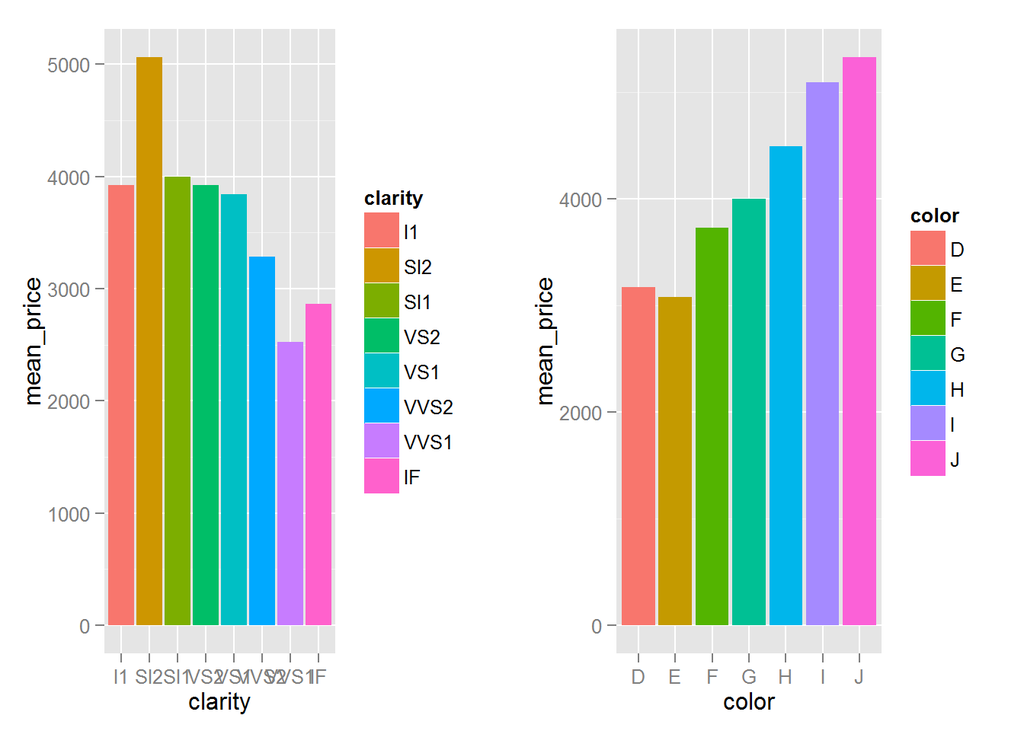

```r
diamonds_by_clarity <- group_by(diamonds, clarity)
diamonds_mp_by_clarity <- summarise(diamonds_by_clarity, mean_price = mean(price))

diamonds_by_color <- group_by(diamonds, color)
diamonds_mp_by_color <- summarise(diamonds_by_color, mean_price = mean(price))

p1  <- ggplot(diamonds_mp_by_clarity, aes(x = clarity, y = mean_price, fill= clarity)) +
  geom_bar(stat = "identity")

p2 <- ggplot(diamonds_mp_by_color, aes(x = color, y = mean_price, fill= color)) +
  geom_bar(stat = "identity")

grid.arrange(p1,p2, ncol =2)
```

s12 has the best mean price whereas VVS1 has the worst mean price. However ther wasn’t a very big change in other groups

mean price for color increase from D to J. J has the best mean price and D and E has the worst mean price. This is agains the odds.

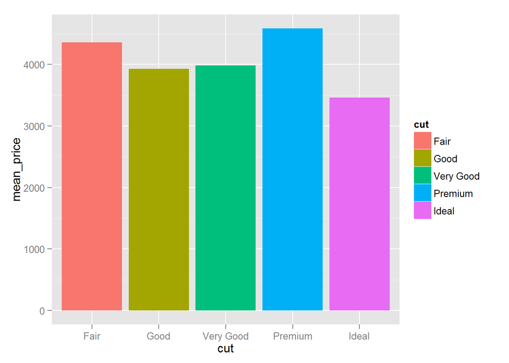

```r
diamonds_by_cut <- group_by(diamonds, cut)
diamonds_mp_by_cut <- summarise(diamonds_by_cut, mean_price = mean(price))

ggplot(diamonds_mp_by_cut, aes(x = cut, y = mean_price, fill= cut)) +
  geom_bar(stat = "identity")
```